# examples_0402

A large square comprises a yellow square, two congruent blue rectangles, and a red square.

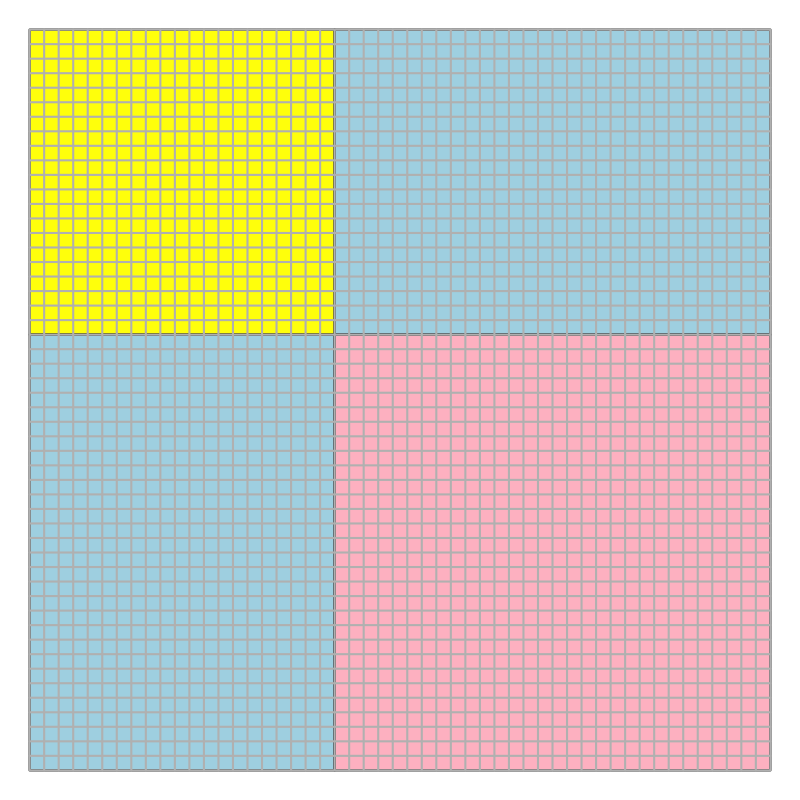

The yellow square has an area of 441 little squares. The two blue rectangles have a combined area of 1260 little squares.

What is the area, in little squares, of the red square?

Find the edge length of the yellow square by using the square-root operator.

$$x=\sqrt{441}$$

$$x=21$$

Find the area of each blue rectangle.

$$B=\frac{1260}{2}$$
$$B=630$$

Each blue rectangle has one length of 21 and another of length $y$.

$$xy~=~630$$
$$21y~=~630$$
$$y~=~30$$

The red square has side lengths equal to $y=30$. To find its area, square the side length.

$$R=y^2$$
$$R=30^2$$
$$R=900$$

The area of the red square is 900 little squares.

A large square comprises a yellow square, two congruent blue rectangles, and a red square.

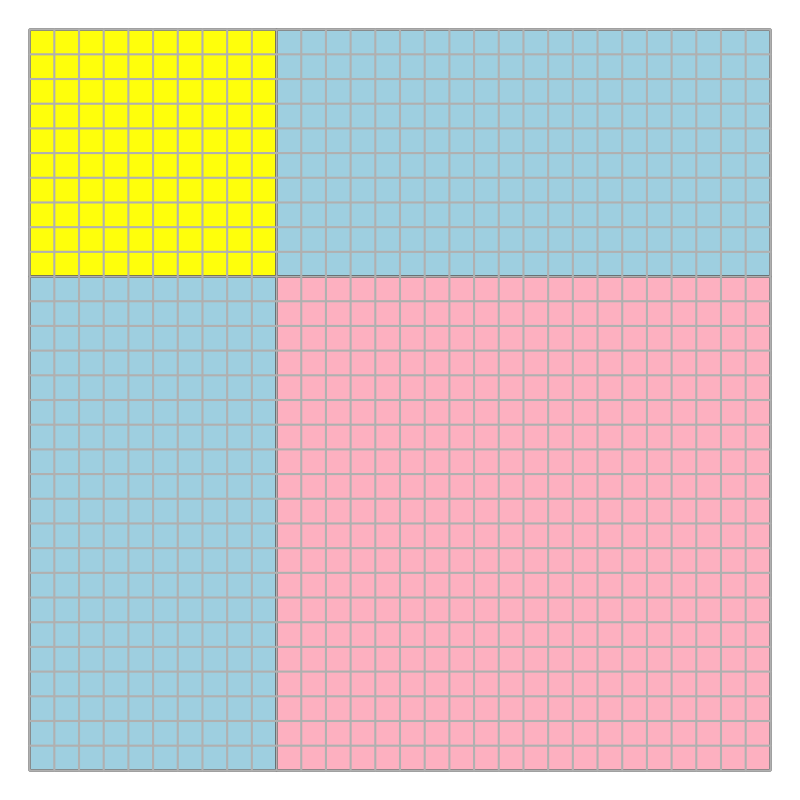

The yellow square has an area of 100 little squares. The two blue rectangles have a combined area of 400 little squares.

What is the area, in little squares, of the red square?

Find the edge length of the yellow square by using the square-root operator.

$$x=\sqrt{100}$$

$$x=10$$

Find the area of each blue rectangle.

$$B=\frac{400}{2}$$
$$B=200$$

Each blue rectangle has one length of 10 and another of length $y$.

$$xy~=~200$$
$$10y~=~200$$
$$y~=~20$$

The red square has side lengths equal to $y=20$. To find its area, square the side length.

$$R=y^2$$
$$R=20^2$$
$$R=400$$

The area of the red square is 400 little squares.

A large square comprises a yellow square, two congruent blue rectangles, and a red square.

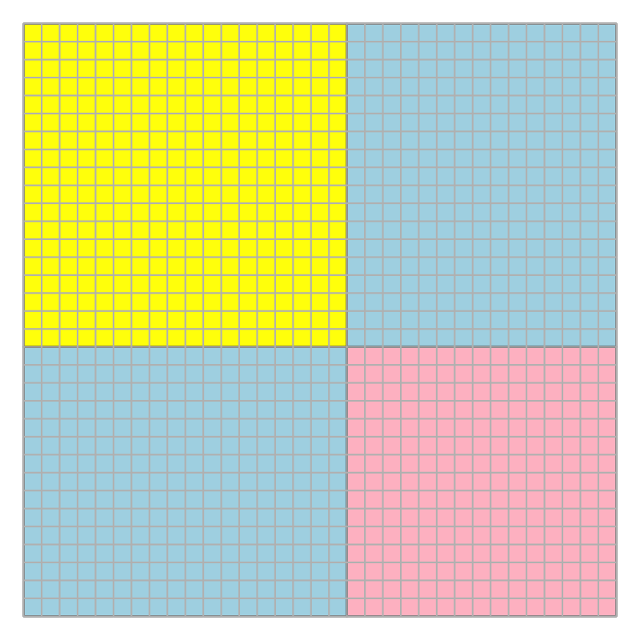

The yellow square has an area of 324 little squares. The two blue rectangles have a combined area of 540 little squares.

What is the area, in little squares, of the red square?

Find the edge length of the yellow square by using the square-root operator.

$$x=\sqrt{324}$$

$$x=18$$

Find the area of each blue rectangle.

$$B=\frac{540}{2}$$
$$B=270$$

Each blue rectangle has one length of 18 and another of length $y$.

$$xy~=~270$$
$$18y~=~270$$
$$y~=~15$$

The red square has side lengths equal to $y=15$. To find its area, square the side length.

$$R=y^2$$
$$R=15^2$$
$$R=225$$

The area of the red square is 225 little squares.

A large square comprises a yellow square, two congruent blue rectangles, and a red square.

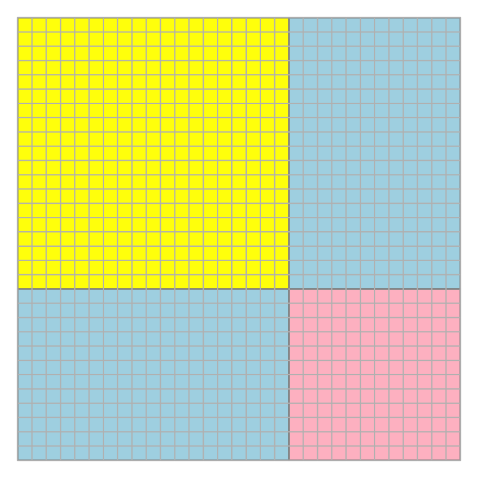

The yellow square has an area of 361 little squares. The two blue rectangles have a combined area of 456 little squares.

What is the area, in little squares, of the red square?

Find the edge length of the yellow square by using the square-root operator.

$$x=\sqrt{361}$$

$$x=19$$

Find the area of each blue rectangle.

$$B=\frac{456}{2}$$
$$B=228$$

Each blue rectangle has one length of 19 and another of length $y$.

$$xy~=~228$$
$$19y~=~228$$
$$y~=~12$$

The red square has side lengths equal to $y=12$. To find its area, square the side length.

$$R=y^2$$
$$R=12^2$$
$$R=144$$

The area of the red square is 144 little squares.

A large square comprises a yellow square, two congruent blue rectangles, and a red square.

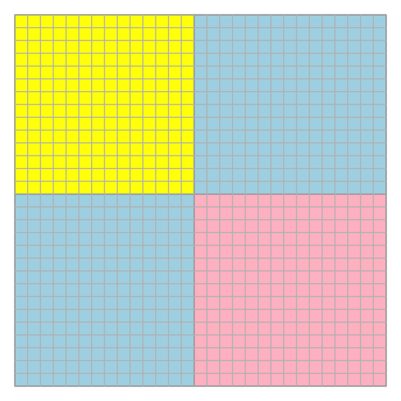

The yellow square has an area of 196 little squares. The two blue rectangles have a combined area of 420 little squares.

What is the area, in little squares, of the red square?

Find the edge length of the yellow square by using the square-root operator.

$$x=\sqrt{196}$$

$$x=14$$

Find the area of each blue rectangle.

$$B=\frac{420}{2}$$
$$B=210$$

Each blue rectangle has one length of 14 and another of length $y$.

$$xy~=~210$$
$$14y~=~210$$
$$y~=~15$$

The red square has side lengths equal to $y=15$. To find its area, square the side length.

$$R=y^2$$
$$R=15^2$$
$$R=225$$

The area of the red square is 225 little squares.

A large square comprises a yellow square, two congruent blue rectangles, and a red square.

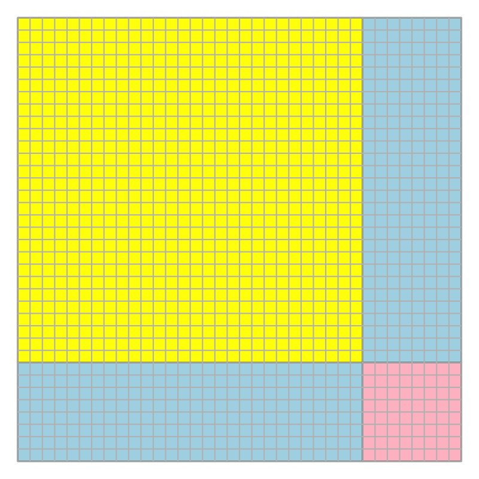

The yellow square has an area of 784 little squares. The two blue rectangles have a combined area of 448 little squares.

What is the area, in little squares, of the red square?

Find the edge length of the yellow square by using the square-root operator.

$$x=\sqrt{784}$$

$$x=28$$

Find the area of each blue rectangle.

$$B=\frac{448}{2}$$
$$B=224$$

Each blue rectangle has one length of 28 and another of length $y$.

$$xy~=~224$$
$$28y~=~224$$
$$y~=~8$$

The red square has side lengths equal to $y=8$. To find its area, square the side length.

$$R=y^2$$
$$R=8^2$$
$$R=64$$

The area of the red square is 64 little squares.

A large square comprises a yellow square, two congruent blue rectangles, and a red square.

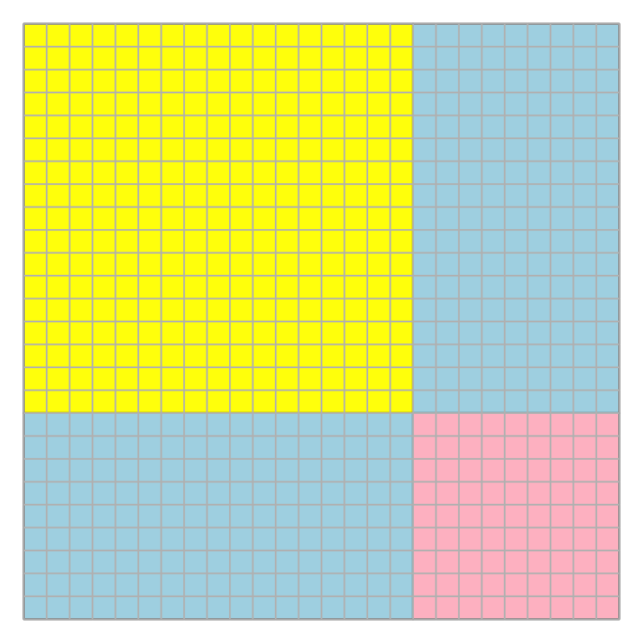

The yellow square has an area of 289 little squares. The two blue rectangles have a combined area of 306 little squares.

What is the area, in little squares, of the red square?

Find the edge length of the yellow square by using the square-root operator.

$$x=\sqrt{289}$$

$$x=17$$

Find the area of each blue rectangle.

$$B=\frac{306}{2}$$
$$B=153$$

Each blue rectangle has one length of 17 and another of length $y$.

$$xy~=~153$$
$$17y~=~153$$
$$y~=~9$$

The red square has side lengths equal to $y=9$. To find its area, square the side length.

$$R=y^2$$
$$R=9^2$$
$$R=81$$

The area of the red square is 81 little squares.

A large square comprises a yellow square, two congruent blue rectangles, and a red square.

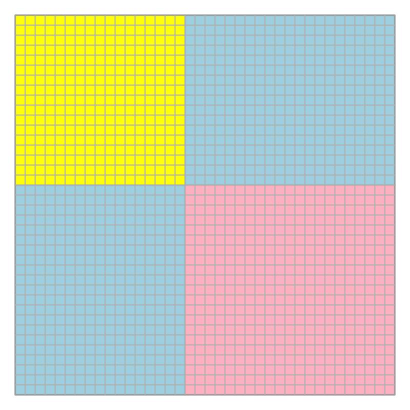

The yellow square has an area of 289 little squares. The two blue rectangles have a combined area of 714 little squares.

What is the area, in little squares, of the red square?

Find the edge length of the yellow square by using the square-root operator.

$$x=\sqrt{289}$$

$$x=17$$

Find the area of each blue rectangle.

$$B=\frac{714}{2}$$
$$B=357$$

Each blue rectangle has one length of 17 and another of length $y$.

$$xy~=~357$$
$$17y~=~357$$
$$y~=~21$$

The red square has side lengths equal to $y=21$. To find its area, square the side length.

$$R=y^2$$
$$R=21^2$$
$$R=441$$

The area of the red square is 441 little squares.

A large square comprises a yellow square, two congruent blue rectangles, and a red square.

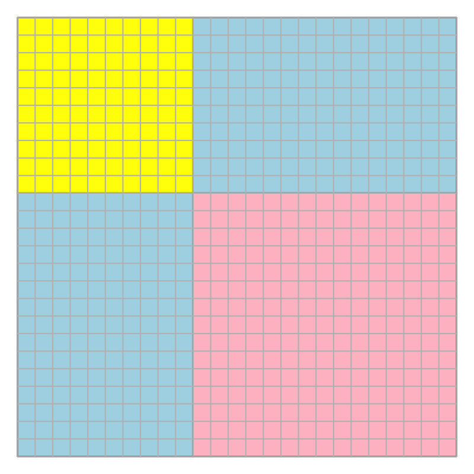

The yellow square has an area of 100 little squares. The two blue rectangles have a combined area of 300 little squares.

What is the area, in little squares, of the red square?

Find the edge length of the yellow square by using the square-root operator.

$$x=\sqrt{100}$$

$$x=10$$

Find the area of each blue rectangle.

$$B=\frac{300}{2}$$
$$B=150$$

Each blue rectangle has one length of 10 and another of length $y$.

$$xy~=~150$$
$$10y~=~150$$
$$y~=~15$$

The red square has side lengths equal to $y=15$. To find its area, square the side length.

$$R=y^2$$
$$R=15^2$$
$$R=225$$

The area of the red square is 225 little squares.

A large square comprises a yellow square, two congruent blue rectangles, and a red square.

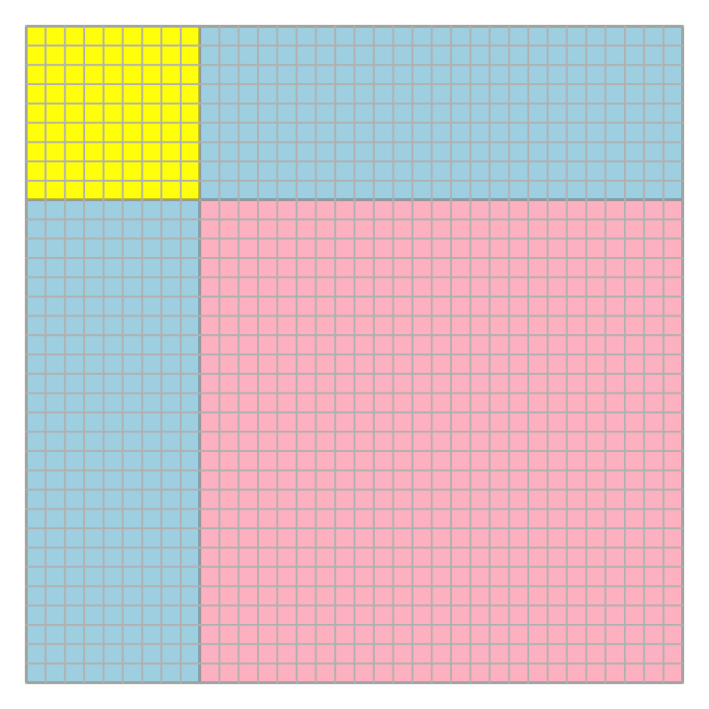

The yellow square has an area of 81 little squares. The two blue rectangles have a combined area of 450 little squares.

What is the area, in little squares, of the red square?

Find the edge length of the yellow square by using the square-root operator.

$$x=\sqrt{81}$$

$$x=9$$

Find the area of each blue rectangle.

$$B=\frac{450}{2}$$
$$B=225$$

Each blue rectangle has one length of 9 and another of length $y$.

$$xy~=~225$$
$$9y~=~225$$
$$y~=~25$$

The red square has side lengths equal to $y=25$. To find its area, square the side length.

$$R=y^2$$
$$R=25^2$$
$$R=625$$

The area of the red square is 625 little squares.

A large square comprises a yellow square, two congruent blue rectangles, and a red square.

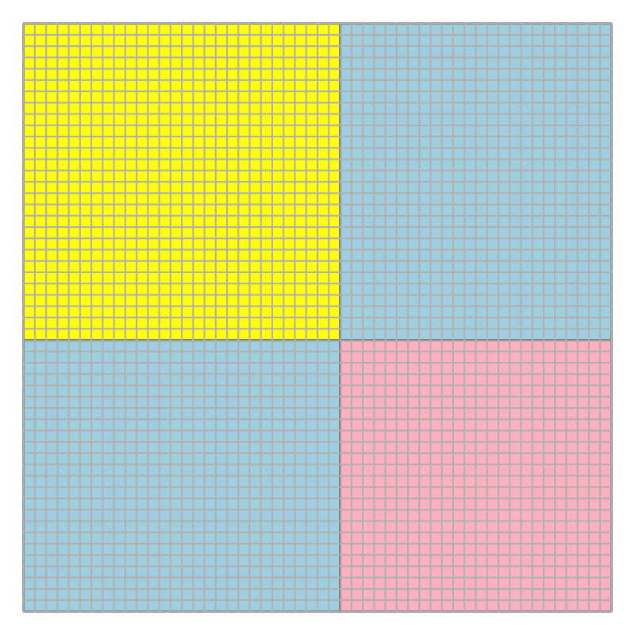

The yellow square has an area of 784 little squares. The two blue rectangles have a combined area of 1344 little squares.

What is the area, in little squares, of the red square?

Find the edge length of the yellow square by using the square-root operator.

$$x=\sqrt{784}$$

$$x=28$$

Find the area of each blue rectangle.

$$B=\frac{1344}{2}$$
$$B=672$$

Each blue rectangle has one length of 28 and another of length $y$.

$$xy~=~672$$
$$28y~=~672$$
$$y~=~24$$

The red square has side lengths equal to $y=24$. To find its area, square the side length.

$$R=y^2$$
$$R=24^2$$
$$R=576$$

The area of the red square is 576 little squares.

A large square comprises a yellow square, two congruent blue rectangles, and a red square.

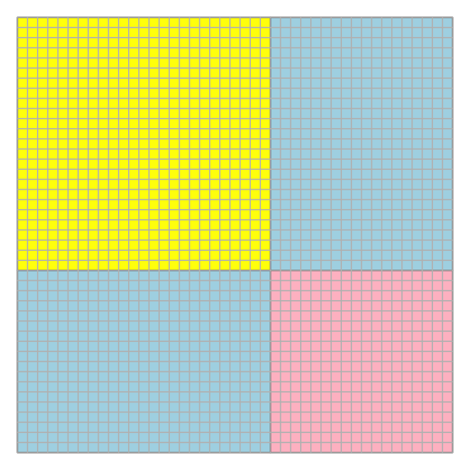

The yellow square has an area of 625 little squares. The two blue rectangles have a combined area of 900 little squares.

What is the area, in little squares, of the red square?

Find the edge length of the yellow square by using the square-root operator.

$$x=\sqrt{625}$$

$$x=25$$

Find the area of each blue rectangle.

$$B=\frac{900}{2}$$
$$B=450$$

Each blue rectangle has one length of 25 and another of length $y$.

$$xy~=~450$$
$$25y~=~450$$
$$y~=~18$$

The red square has side lengths equal to $y=18$. To find its area, square the side length.

$$R=y^2$$
$$R=18^2$$
$$R=324$$

The area of the red square is 324 little squares.

A large square comprises a yellow square, two congruent blue rectangles, and a red square.

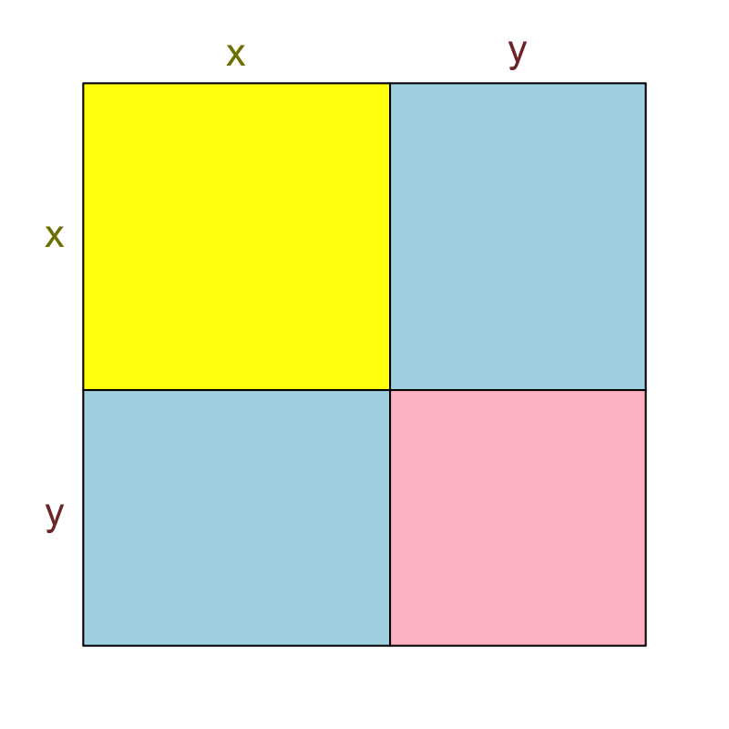

The yellow square has an area of $x^2$ square units. The two blue rectangles have a combined area of $20x$ square units.

What is the area, in square units, of the red square?

Find the area of each blue rectangle.

$$B=\frac{20x}{2}$$
$$B=10x$$

Each blue rectangle has one length of $x$ and another of length $10$.

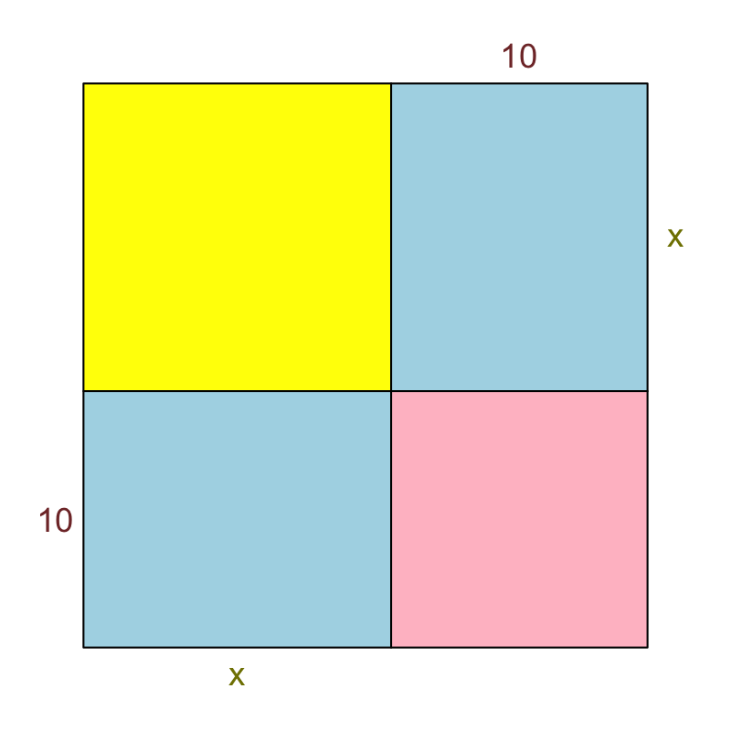

The red square has side lengths equal to $y=10$. To find its area, square the side length.

$$R=y^2$$
$$R=10^2$$
$$R=100$$

The area of the red square is 100 square units.

A large square comprises a yellow square, two congruent blue rectangles, and a red square.

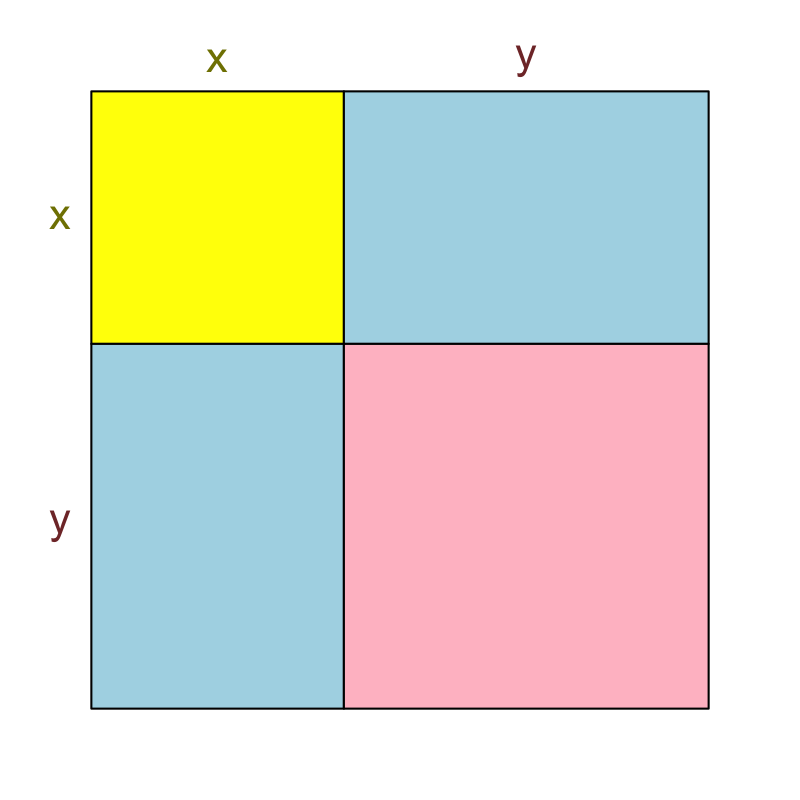

The yellow square has an area of $x^2$ square units. The two blue rectangles have a combined area of $52x$ square units.

What is the area, in square units, of the red square?

Find the area of each blue rectangle.

$$B=\frac{52x}{2}$$
$$B=26x$$

Each blue rectangle has one length of $x$ and another of length $26$.

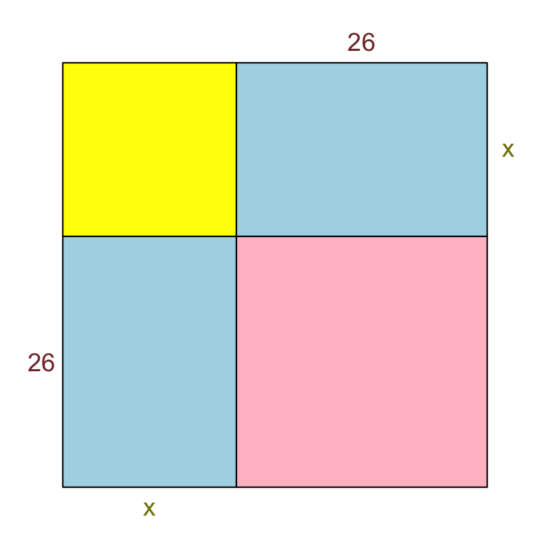

The red square has side lengths equal to $y=26$. To find its area, square the side length.

$$R=y^2$$
$$R=26^2$$
$$R=676$$

The area of the red square is 676 square units.

A large square comprises a yellow square, two congruent blue rectangles, and a red square.

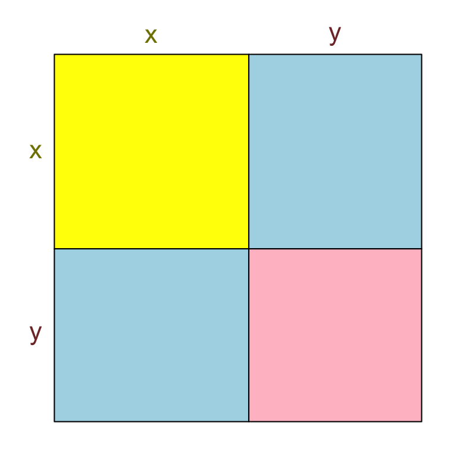

The yellow square has an area of $x^2$ square units. The two blue rectangles have a combined area of $48x$ square units.

What is the area, in square units, of the red square?

Find the area of each blue rectangle.

$$B=\frac{48x}{2}$$
$$B=24x$$

Each blue rectangle has one length of $x$ and another of length $24$.

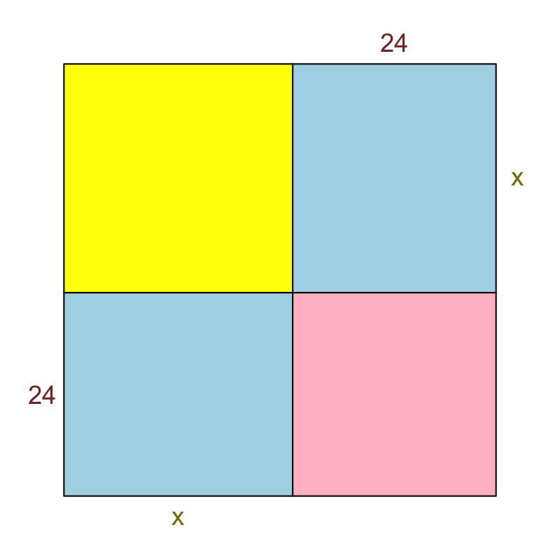

The red square has side lengths equal to $y=24$. To find its area, square the side length.

$$R=y^2$$
$$R=24^2$$
$$R=576$$

The area of the red square is 576 square units.

A large square comprises a yellow square, two congruent blue rectangles, and a red square.

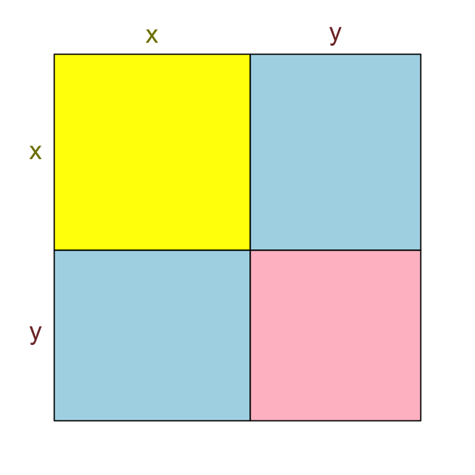

The yellow square has an area of $x^2$ square units. The two blue rectangles have a combined area of $40x$ square units.

What is the area, in square units, of the red square?

Find the area of each blue rectangle.

$$B=\frac{40x}{2}$$
$$B=20x$$

Each blue rectangle has one length of $x$ and another of length $20$.

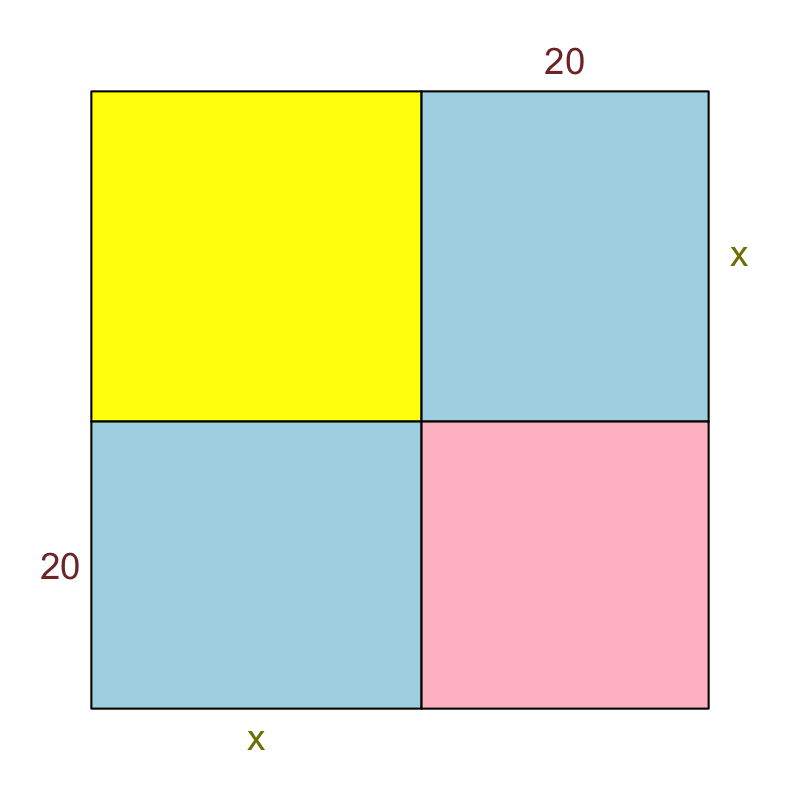

The red square has side lengths equal to $y=20$. To find its area, square the side length.

$$R=y^2$$
$$R=20^2$$
$$R=400$$

The area of the red square is 400 square units.

A large square comprises a yellow square, two congruent blue rectangles, and a red square.

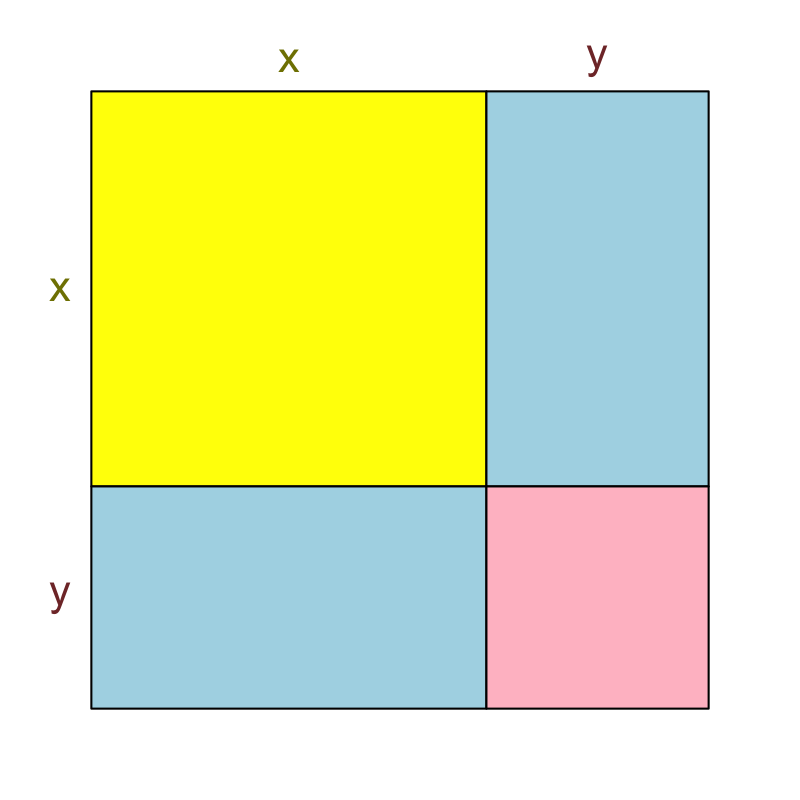

The yellow square has an area of $x^2$ square units. The two blue rectangles have a combined area of $18x$ square units.

What is the area, in square units, of the red square?

Find the area of each blue rectangle.

$$B=\frac{18x}{2}$$
$$B=9x$$

Each blue rectangle has one length of $x$ and another of length $9$.

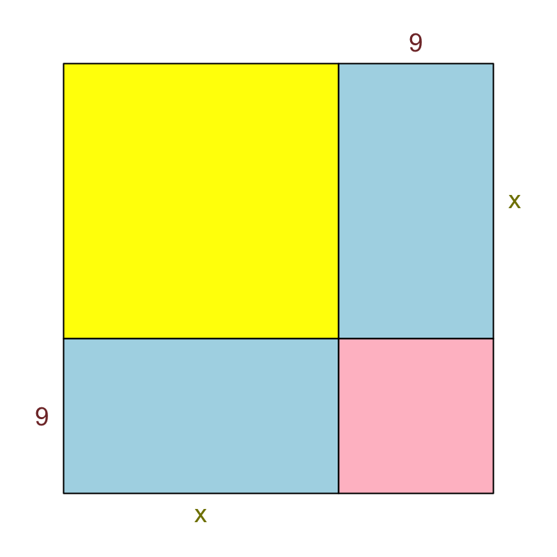

The red square has side lengths equal to $y=9$. To find its area, square the side length.

$$R=y^2$$
$$R=9^2$$
$$R=81$$

The area of the red square is 81 square units.

A large square comprises a yellow square, two congruent blue rectangles, and a red square.

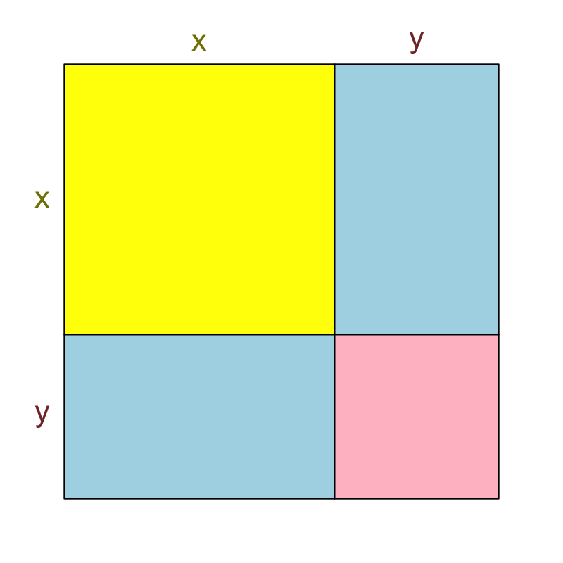

The yellow square has an area of $x^2$ square units. The two blue rectangles have a combined area of $34x$ square units.

What is the area, in square units, of the red square?

Find the area of each blue rectangle.

$$B=\frac{34x}{2}$$
$$B=17x$$

Each blue rectangle has one length of $x$ and another of length $17$.

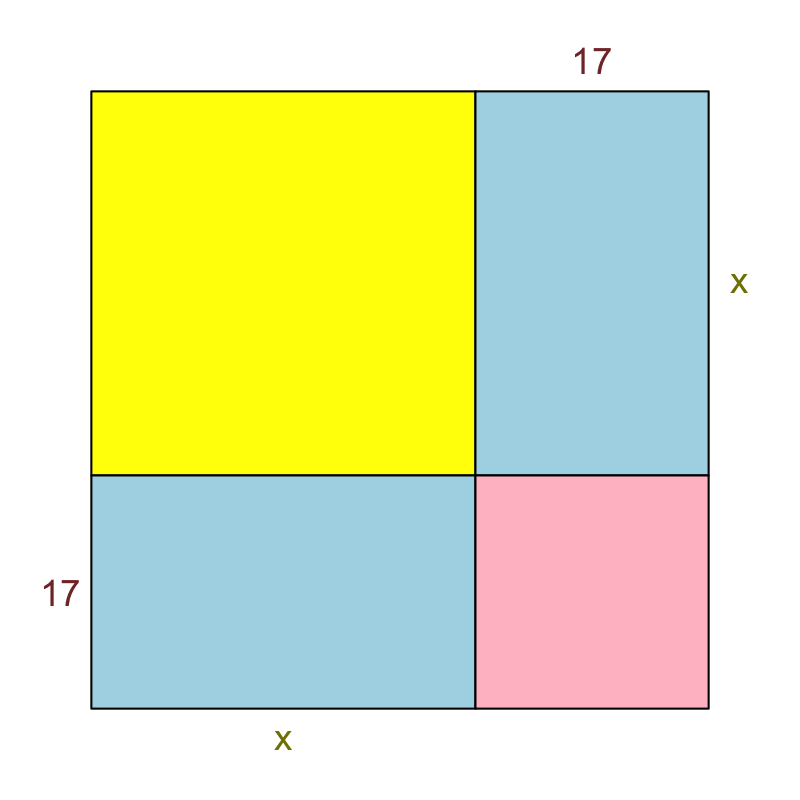

The red square has side lengths equal to $y=17$. To find its area, square the side length.

$$R=y^2$$
$$R=17^2$$
$$R=289$$

The area of the red square is 289 square units.

A large square comprises a yellow square, two congruent blue rectangles, and a red square.

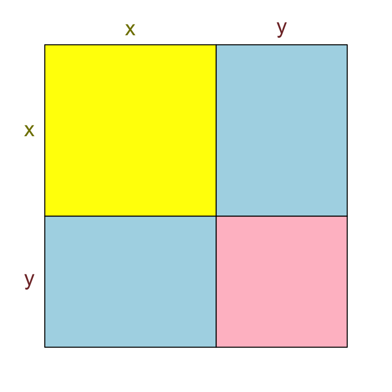

The yellow square has an area of $x^2$ square units. The two blue rectangles have a combined area of $26x$ square units.

What is the area, in square units, of the red square?

Find the area of each blue rectangle.

$$B=\frac{26x}{2}$$
$$B=13x$$

Each blue rectangle has one length of $x$ and another of length $13$.

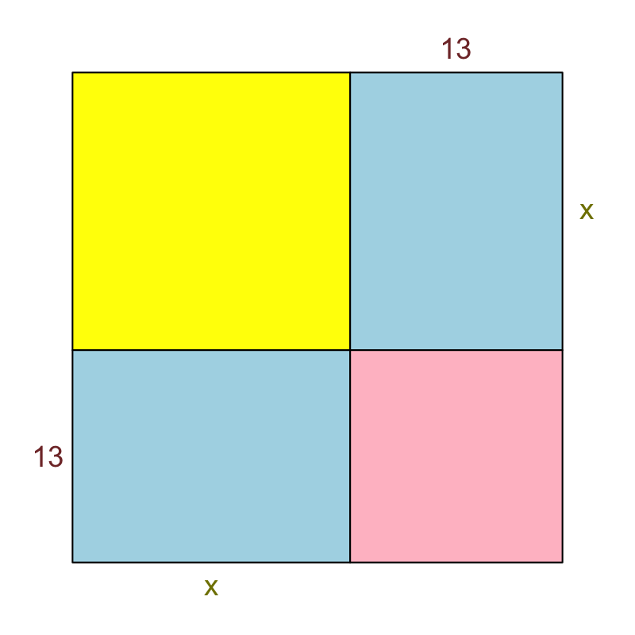

The red square has side lengths equal to $y=13$. To find its area, square the side length.

$$R=y^2$$
$$R=13^2$$
$$R=169$$

The area of the red square is 169 square units.

A large square comprises a yellow square, two congruent blue rectangles, and a red square.

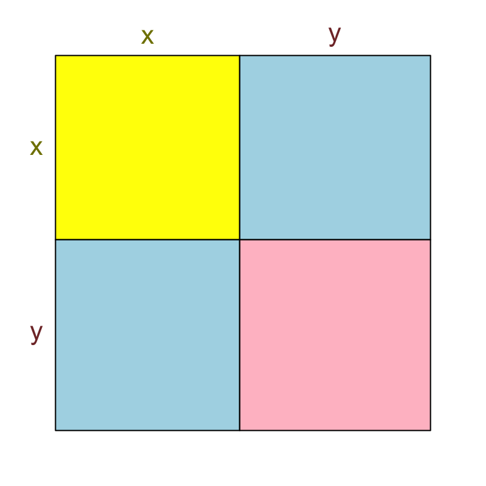

The yellow square has an area of $x^2$ square units. The two blue rectangles have a combined area of $58x$ square units.

What is the area, in square units, of the red square?

Find the area of each blue rectangle.

$$B=\frac{58x}{2}$$
$$B=29x$$

Each blue rectangle has one length of $x$ and another of length $29$.

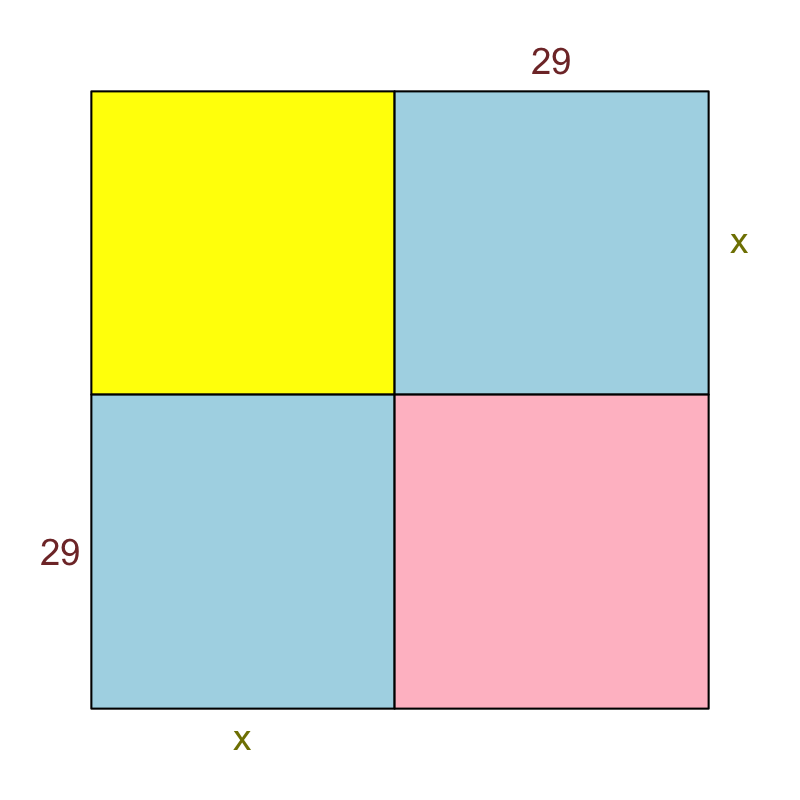

The red square has side lengths equal to $y=29$. To find its area, square the side length.

$$R=y^2$$
$$R=29^2$$
$$R=841$$

The area of the red square is 841 square units.

A large square comprises a yellow square, two congruent blue rectangles, and a red square.

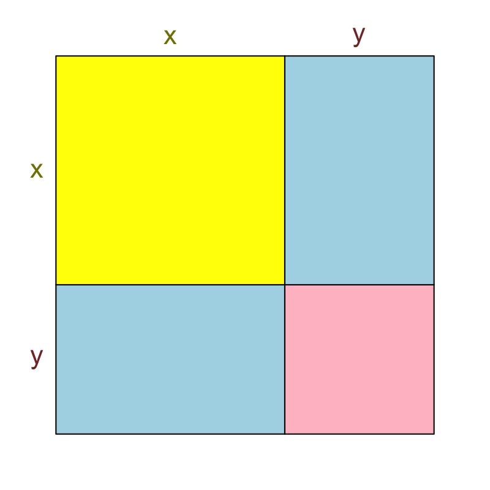

The yellow square has an area of $x^2$ square units. The two blue rectangles have a combined area of $30x$ square units.

What is the area, in square units, of the red square?

Find the area of each blue rectangle.

$$B=\frac{30x}{2}$$
$$B=15x$$

Each blue rectangle has one length of $x$ and another of length $15$.

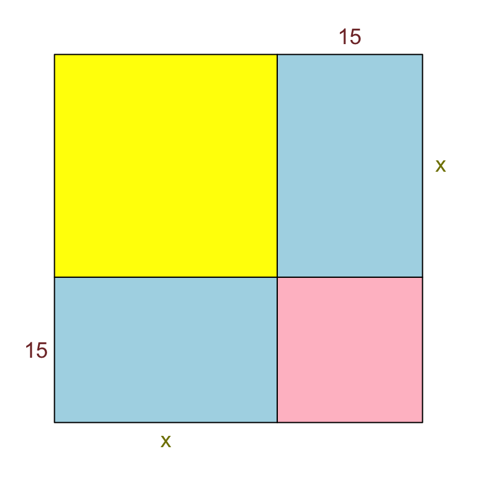

The red square has side lengths equal to $y=15$. To find its area, square the side length.

$$R=y^2$$
$$R=15^2$$
$$R=225$$

The area of the red square is 225 square units.

A large square comprises a yellow square, two congruent blue rectangles, and a red square.

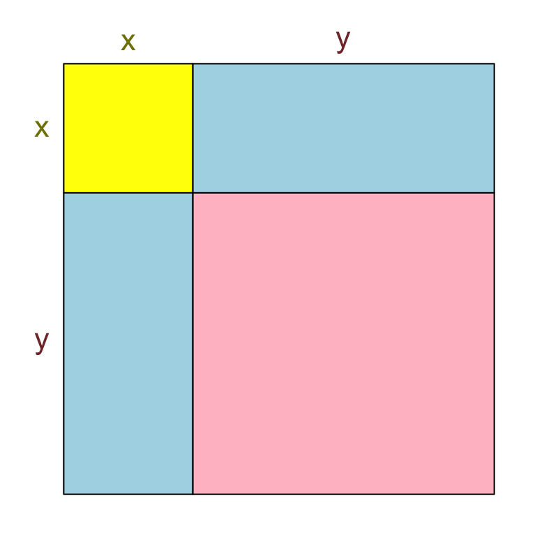

The yellow square has an area of $x^2$ square units. The two blue rectangles have a combined area of $56x$ square units.

What is the area, in square units, of the red square?

Find the area of each blue rectangle.

$$B=\frac{56x}{2}$$
$$B=28x$$

Each blue rectangle has one length of $x$ and another of length $28$.

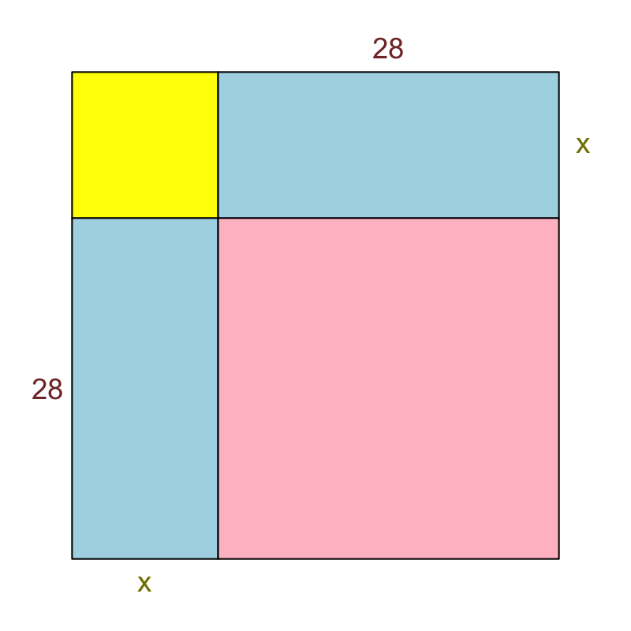

The red square has side lengths equal to $y=28$. To find its area, square the side length.

$$R=y^2$$
$$R=28^2$$
$$R=784$$

The area of the red square is 784 square units.